# Tutorial

## Outcome of the tutorial

- Create and distinguish data types in R
- Know how to create vectors
- Use functions in R
- Use the ggplot package
- Create heatmaps using gplots

## R basics

```r
a <- 20
b <- 10

a+b
```

```
## [1] 30
```

```r
c(a,b)
```

```
## [1] 20 10
```

## Vectors

R works with vectors of different kinds which is similar to other programming languages.

```r
numbers <- c(1,2,3,4,5)
a <- seq(5)

sum(a)
```

```
## [1] 15
```

```r
length(a)
```

```
## [1] 5
```

```r
class(a)
```

```
## [1] "integer"
```

## Character Vectors

```r
letters
```

```
##  [1] "a" "b" "c" "d" "e" "f" "g" "h" "i" "j" "k" "l" "m" "n" "o" "p" "q"
## [18] "r" "s" "t" "u" "v" "w" "x" "y" "z"
```

```r
class(letters)
```

```
## [1] "character"
```

```r
b <- letters[1:20]
c <- letters[10:20]
d <- letters[15:25]

tmp1 <- union(b,c)
finalUnion <- union(tmp1, d)
```

## Exercise 1

- What do the `length()` and `class()` functions tell you?
- How does the `union()` function differ from the `c()` function? Compare using the b and c variable above
- How can you find the shared characters between b and c? Tip: Try the help function on `union()`
- Try out the function on objects `b` and `c` you found in the last code snippet
- - Create one integer vector which spans 10 to 20 and 30 to 60.

Tips: - Use the help function like this: `?seq`

## Data frames

R’s most common data structure is the data frame which is a table containing different numeric values, as well as descriptive values like characters or factors.

```r
head(iris)
```

```
##   Sepal.Length Sepal.Width Petal.Length Petal.Width Species
## 1          5.1         3.5          1.4         0.2  setosa
## 2          4.9         3.0          1.4         0.2  setosa
## 3          4.7         3.2          1.3         0.2  setosa
## 4          4.6         3.1          1.5         0.2  setosa
## 5          5.0         3.6          1.4         0.2  setosa
## 6          5.4         3.9          1.7         0.4  setosa
```

## GGPLOT Basics

- ggplot2 is a package to create plots
- It follows the grammar of graphics principle.
- You need to import the package before using it (i.e. execute the following line of code)
- Tip: Import all the packages you need at the top of the script

```r
library(ggplot2)
```

## The iris dataset

```r
library(ggplot2)
ggplot(iris, aes(x = Sepal.Length,
                 y = Petal.Length,
                 color = Species))+
  geom_point()
```

## The iris dataset

The Result:

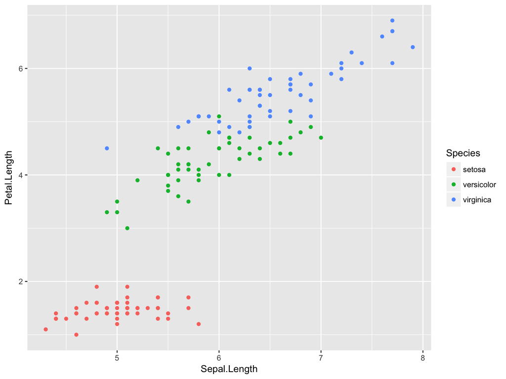

## GGplot step by step

Demo

## Inspecting a dataset

```r
iris$Species
```

```
##   [1] setosa     setosa     setosa     setosa     setosa     setosa
##   [7] setosa     setosa     setosa     setosa     setosa     setosa
##  [13] setosa     setosa     setosa     setosa     setosa     setosa
##  [19] setosa     setosa     setosa     setosa     setosa     setosa
##  [25] setosa     setosa     setosa     setosa     setosa     setosa
##  [31] setosa     setosa     setosa     setosa     setosa     setosa
##  [37] setosa     setosa     setosa     setosa     setosa     setosa
##  [43] setosa     setosa     setosa     setosa     setosa     setosa
##  [49] setosa     setosa     versicolor versicolor versicolor versicolor
##  [55] versicolor versicolor versicolor versicolor versicolor versicolor
##  [61] versicolor versicolor versicolor versicolor versicolor versicolor
##  [67] versicolor versicolor versicolor versicolor versicolor versicolor
##  [73] versicolor versicolor versicolor versicolor versicolor versicolor
##  [79] versicolor versicolor versicolor versicolor versicolor versicolor
##  [85] versicolor versicolor versicolor versicolor versicolor versicolor
##  [91] versicolor versicolor versicolor versicolor versicolor versicolor
##  [97] versicolor versicolor versicolor versicolor virginica  virginica
## [103] virginica  virginica  virginica  virginica  virginica  virginica
## [109] virginica  virginica  virginica  virginica  virginica  virginica
## [115] virginica  virginica  virginica  virginica  virginica  virginica
## [121] virginica  virginica  virginica  virginica  virginica  virginica
## [127] virginica  virginica  virginica  virginica  virginica  virginica
## [133] virginica  virginica  virginica  virginica  virginica  virginica
## [139] virginica  virginica  virginica  virginica  virginica  virginica
## [145] virginica  virginica  virginica  virginica  virginica  virginica
## Levels: setosa versicolor virginica
```

## Inspecting a dataset

```r
iris$Species == 'setosa'
```

```
##   [1]  TRUE  TRUE  TRUE  TRUE  TRUE  TRUE  TRUE  TRUE  TRUE  TRUE  TRUE
##  [12]  TRUE  TRUE  TRUE  TRUE  TRUE  TRUE  TRUE  TRUE  TRUE  TRUE  TRUE
##  [23]  TRUE  TRUE  TRUE  TRUE  TRUE  TRUE  TRUE  TRUE  TRUE  TRUE  TRUE
##  [34]  TRUE  TRUE  TRUE  TRUE  TRUE  TRUE  TRUE  TRUE  TRUE  TRUE  TRUE
##  [45]  TRUE  TRUE  TRUE  TRUE  TRUE  TRUE FALSE FALSE FALSE FALSE FALSE
##  [56] FALSE FALSE FALSE FALSE FALSE FALSE FALSE FALSE FALSE FALSE FALSE
##  [67] FALSE FALSE FALSE FALSE FALSE FALSE FALSE FALSE FALSE FALSE FALSE
##  [78] FALSE FALSE FALSE FALSE FALSE FALSE FALSE FALSE FALSE FALSE FALSE
##  [89] FALSE FALSE FALSE FALSE FALSE FALSE FALSE FALSE FALSE FALSE FALSE
## [100] FALSE FALSE FALSE FALSE FALSE FALSE FALSE FALSE FALSE FALSE FALSE
## [111] FALSE FALSE FALSE FALSE FALSE FALSE FALSE FALSE FALSE FALSE FALSE
## [122] FALSE FALSE FALSE FALSE FALSE FALSE FALSE FALSE FALSE FALSE FALSE
## [133] FALSE FALSE FALSE FALSE FALSE FALSE FALSE FALSE FALSE FALSE FALSE
## [144] FALSE FALSE FALSE FALSE FALSE FALSE FALSE
```

## Inspecting a dataset

We can combine the two vectors shown before:

```r
iris$Species[iris$Species == 'setosa']
```

```
##  [1] setosa setosa setosa setosa setosa setosa setosa setosa setosa setosa
## [11] setosa setosa setosa setosa setosa setosa setosa setosa setosa setosa
## [21] setosa setosa setosa setosa setosa setosa setosa setosa setosa setosa
## [31] setosa setosa setosa setosa setosa setosa setosa setosa setosa setosa
## [41] setosa setosa setosa setosa setosa setosa setosa setosa setosa setosa
## Levels: setosa versicolor virginica
```

## Inspecting a dataset

```r
iris[iris$Species == 'setosa',]
```

```
##    Sepal.Length Sepal.Width Petal.Length Petal.Width Species
## 1           5.1         3.5          1.4         0.2  setosa
## 2           4.9         3.0          1.4         0.2  setosa
## 3           4.7         3.2          1.3         0.2  setosa
## 4           4.6         3.1          1.5         0.2  setosa
## 5           5.0         3.6          1.4         0.2  setosa
## 6           5.4         3.9          1.7         0.4  setosa
## 7           4.6         3.4          1.4         0.3  setosa
## 8           5.0         3.4          1.5         0.2  setosa
## 9           4.4         2.9          1.4         0.2  setosa
## 10          4.9         3.1          1.5         0.1  setosa
## 11          5.4         3.7          1.5         0.2  setosa
## 12          4.8         3.4          1.6         0.2  setosa
## 13          4.8         3.0          1.4         0.1  setosa
## 14          4.3         3.0          1.1         0.1  setosa
```

[output cut: 36 more lines]

## Inspecting a dataset

Try out the following statements in your script:

```r
iris
iris$Species
iris$Species == 'setosa'
subset(iris, Species == 'setosa') # same as above
iris$Species %in% c('setosa', 'versicolor')
iris$Species[iris$Species %in% c('setosa', 'versicolor')]
iris[iris$Species %in% c('setosa', 'versicolor'),]
iris[c(1,2,3),]
iris[,c(1,2)]
```

## Merging data

```r
poison <- data.frame(
  poisonous = c('poisonous', 'non-poisonous', 'non-poisonous'),
  Species = c('setosa', 'virginica', 'versicolor')
  )

pplants <- merge(iris, poison, by = "Species")

head(pplants) # What happened to the dataset?
```

```
##   Species Sepal.Length Sepal.Width Petal.Length Petal.Width poisonous
## 1  setosa          5.1         3.5          1.4         0.2 poisonous
## 2  setosa          4.9         3.0          1.4         0.2 poisonous
## 3  setosa          4.7         3.2          1.3         0.2 poisonous
## 4  setosa          4.6         3.1          1.5         0.2 poisonous
## 5  setosa          5.0         3.6          1.4         0.2 poisonous
## 6  setosa          5.4         3.9          1.7         0.4 poisonous
```

```r
aggregate( Petal.Length~poisonous, pplants, mean)
```

```
##       poisonous Petal.Length
## 1 non-poisonous        4.906
## 2     poisonous        1.462
```

## Assign a new column

```r
pplants$combined_label <- paste(pplants$Species,
                                pplants$poison,
                                sep = "_")

head(pplants)
```

```
##   Species Sepal.Length Sepal.Width Petal.Length Petal.Width poisonous
## 1  setosa          5.1         3.5          1.4         0.2 poisonous
## 2  setosa          4.9         3.0          1.4         0.2 poisonous
## 3  setosa          4.7         3.2          1.3         0.2 poisonous
## 4  setosa          4.6         3.1          1.5         0.2 poisonous
## 5  setosa          5.0         3.6          1.4         0.2 poisonous
## 6  setosa          5.4         3.9          1.7         0.4 poisonous
##     combined_label
## 1 setosa_poisonous
## 2 setosa_poisonous
## 3 setosa_poisonous
## 4 setosa_poisonous
## 5 setosa_poisonous
## 6 setosa_poisonous
```

## GGPLOT geoms

- We used geom_point to create a scatterplot
- There are several more like e.g. `geom_bar()`

```r
ggplot(mtcars, aes(x = factor(cyl), fill = factor(gear))) +
geom_bar(position = 'dodge', stat = 'count', color = "black")
```

## Solution

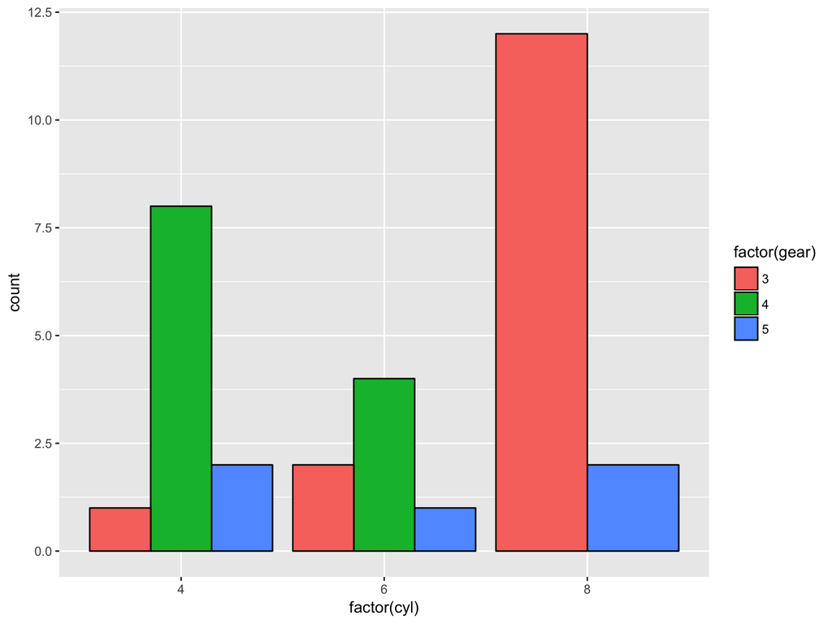

## Using regex in R

```r
rownames(mtcars)[grepl("Merc",rownames(mtcars))]
```

```
## [1] "Merc 240D"   "Merc 230"    "Merc 280"    "Merc 280C"   "Merc 450SE"
## [6] "Merc 450SL"  "Merc 450SLC"
```

## Using regex in R

```r
mtcars[grepl("Merc",rownames(mtcars)),]
```

```
##              mpg cyl  disp  hp drat   wt qsec vs am gear carb
## Merc 240D   24.4   4 146.7  62 3.69 3.19 20.0  1  0    4    2
## Merc 230    22.8   4 140.8  95 3.92 3.15 22.9  1  0    4    2
## Merc 280    19.2   6 167.6 123 3.92 3.44 18.3  1  0    4    4
## Merc 280C   17.8   6 167.6 123 3.92 3.44 18.9  1  0    4    4
## Merc 450SE  16.4   8 275.8 180 3.07 4.07 17.4  0  0    3    3
## Merc 450SL  17.3   8 275.8 180 3.07 3.73 17.6  0  0    3    3
## Merc 450SLC 15.2   8 275.8 180 3.07 3.78 18.0  0  0    3    3
```